# ggstackplot

## Other themes

You aren’t bound to our theme’s aesthetic choices :), you can always add another theme or theme modifications on top of `theme_stackplot()`! Here we add the classic `theme_bw()` to get those nice clean gridlines back, as well as a panel border.

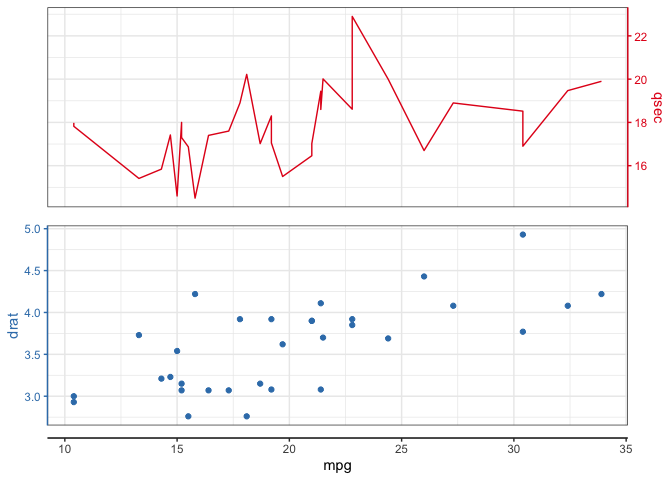

```r
mtcars |>
  ggstackplot(
    x = mpg, y = c(qsec, drat),
    color = c("#E41A1C", "#377EB8"),
    overlap = 0,
    template = ggplot() +
      geom_line(data = function(df) filter(df, .yvar == "qsec")) +
      geom_point(data = function(df) filter(df, .yvar == "drat")) +
      theme_stackplot() +
      theme_bw() # give us that good theme!
  )
```

## Custom geom data

It is possible to use different geoms for different stacked panels. Here, we use both lines and points. These geoms are defined in the `template` argument.

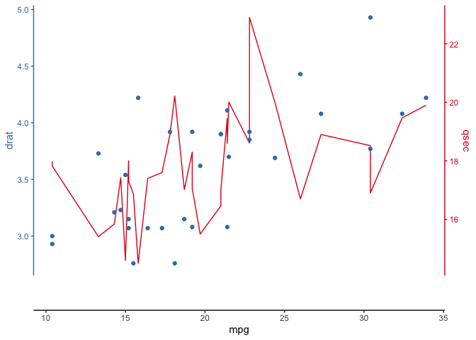

```r
# use different geoms for different panels
# you can refer to y-stack panel variables with `.yvar` and x-stack panel variables with `.xvar`
mtcars |>
  ggstackplot(
    x = mpg, y = c(qsec, drat),
    color = c("#E41A1C", "#377EB8"),
    overlap = 1,
    template = ggplot() +
      geom_line(data = function(df) filter(df, .yvar == "qsec")) +
      geom_point(data = function(df) filter(df, .yvar == "drat")) +
      theme_stackplot()
  )
```

## Different plot elements

One can also change the geoms in the default theme. Here we use `geom_path()` instead of `geom_line()` in a horizontal stack. This is a very common use case because `geom_line()` connects the data points by increasing x-axis which is not always what we want (for example in oceanographic depth plots where we want to connect the data points by increasing y-axis value).

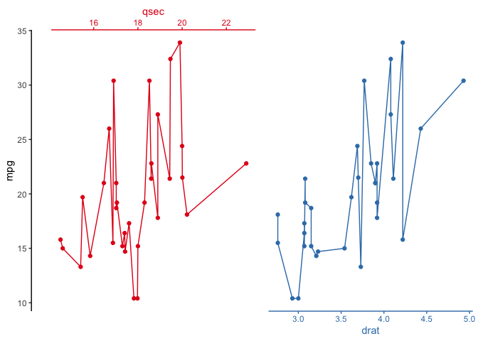

```r
# horizontal stack with default (geom_line())
mtcars |>
  ggstackplot(
    y = mpg, x = c(qsec, drat),
    color = c("#E41A1C", "#377EB8"),
    template =
      ggplot() +
      geom_point() +
      geom_line() + # default in template
      theme_stackplot()
  )
```

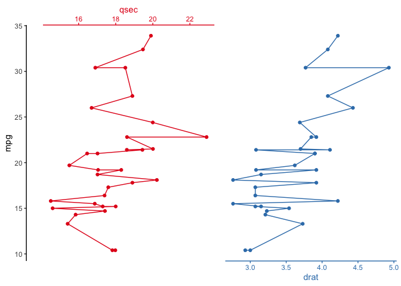

```r
# the following is the exact same data but using a
# horizontal stack with "depth-profile" like geom_path()
mtcars |>
  # arrange data by the y-axis
  arrange(mpg) |>
  ggstackplot(
    y = mpg, x = c(qsec, drat),
    color = c("#E41A1C", "#377EB8"),
    template =
      ggplot() +
      geom_point() +
      geom_path() + # plots data in order
      theme_stackplot()
  )
```

## Additional plot elements

One can also add additional plot elements just as with a normal ggplot. Here we add a vertical line that is shared across all stacked plots:

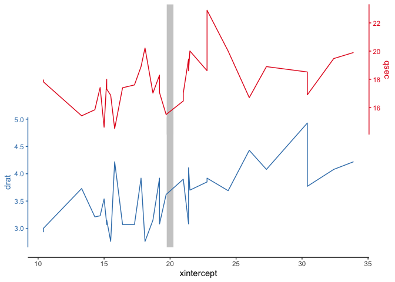

```r
mtcars |>
  ggstackplot(
    x = mpg, y = c(qsec, drat),
    color = c("#E41A1C", "#377EB8"),
    overlap = 0.2,
    template =
      ggplot() +
      geom_vline(xintercept = 20, linewidth = 4, color = "gray80") +
      geom_line() +
      theme_stackplot()
  )
```

## Axis modifications

Sometimes secondary axes will still be desired, especially if that axis is a transformation of an existing one. For example, here, we create a square root mpg axis that is plotted against the mpg axis. All this can also be defined in the `template` argument by adding a `scale_x_continuous` argument, just as you would in a normal ggplot.

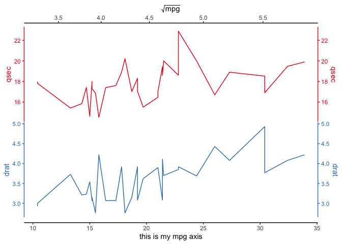

```r
# add a secondary x axis
mtcars |>
  ggstackplot(
    x = mpg, y = c(qsec, drat),
    color = c("#E41A1C", "#377EB8"),
    both_axes = TRUE, overlap = 0.1,
    template =
      ggplot() +
      geom_line() +
      scale_x_continuous(
        # change axis name
        name = "this is my mpg axis",
        # this can be the same with dup_axis() or as here have a transformed axis
        sec.axis = sec_axis(
          transform = sqrt,
          name = expression(sqrt(mpg)),
          breaks = scales::pretty_breaks(5)
        )
      ) +
      theme_stackplot()
  )
```

Similarly, transformation axes can be introduced such as e.g. a log axis.

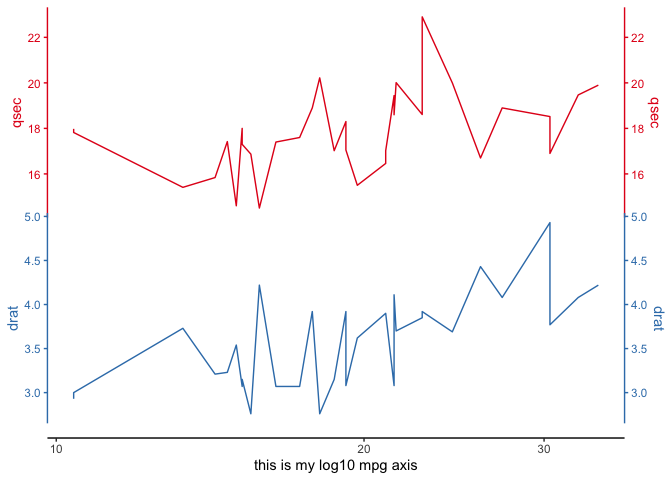

```r
mtcars |>
  ggstackplot(
    x = mpg, y = c(qsec, drat),
    color = c("#E41A1C", "#377EB8"),
    both_axes = TRUE, overlap = 0.1,
    template =
      ggplot() +
      geom_line() +
      scale_x_log10("this is my log10 mpg axis") +
      theme_stackplot()
  )
```

## Additional aesthetics

Aesthetics are also defined in the `template` argument. Remember, the only parameters that are defined in the stackplot are (i) the shared axis (in this case, `mpg` ), (ii) the axes to be stacked, in this case `y = c(wt, qsec, drat)`, (iii) any ggstackplot-specific arguments. All ggplot arguments and aesthetics are assigned in the `template` argument.

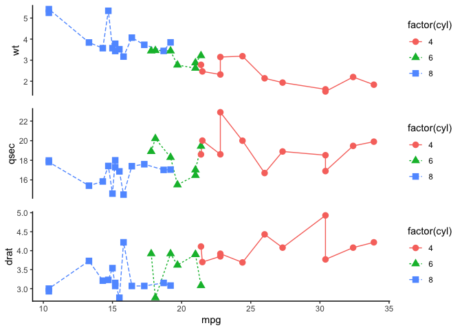

```r
# add aesthetics to the plot
mtcars |>
  ggstackplot(
    x = mpg,  y = c(wt, qsec, drat),
    alternate_axes = FALSE,
    template =
      ggplot() +
      aes(color = factor(cyl), linetype = factor(cyl), shape = factor(cyl)) +
      geom_line() +
      geom_point(size = 3) +
      theme_stackplot()
  )
```

# The `add` argument

For even more specific plot refinements, the `add` argument provides an easy way to add ggplot components to **specific panels** in the stack plot. A few examples below:

## Custom geoms

Similar to the example `custom geom data` the `add` argument can also be used to add specific geoms *only to specific panels.*

This takes the form of a `list()` where each item in the list is of the form: `panel_name = panel_addition` where panel_name is the panel-specific variable and `panel_addition` is the item to `add` (`+`) to that panel. `add` also allows the user to make additions by index (e.g., first panel, second panel, third panel, etc.).

Here, we add a `geom_line` to the `qsec` panel and a `geom_rect` rectangle to the `drat` panel by defining these panels in the `list()`.

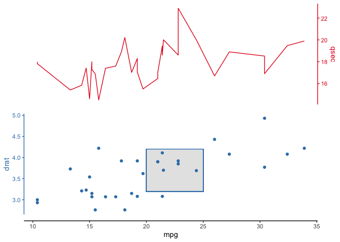

```r
mtcars |>
  ggstackplot(
    x = mpg, y = c(qsec, drat),
    color = c("#E41A1C", "#377EB8"),
    template = ggplot() + theme_stackplot(),
    # add:
    add = list(
      # panel by name
      qsec = geom_line(),
      drat = geom_rect(
        xmin = 20, xmax = 25, ymin = 3.2, ymax = 4.2, fill = "gray90") +
        geom_point()
    )
  )
```

## Custom themes

Similarly, custom theme options can be added to specific panels. Here, we `add` by panel index:

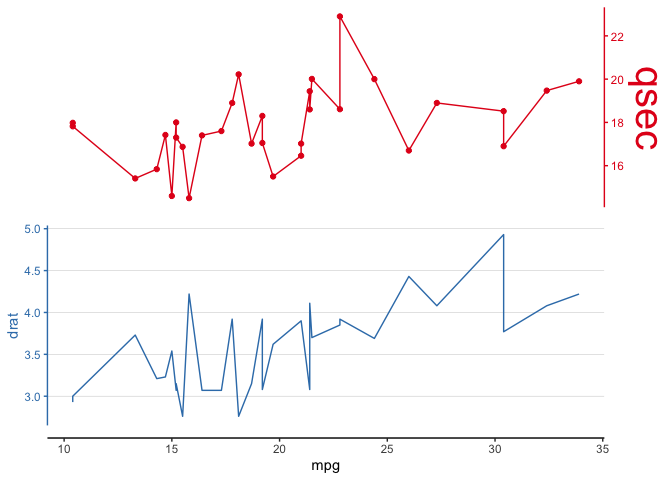

```r
mtcars |>
  ggstackplot(
    x = mpg, y = c(qsec, drat),
    color = c("#E41A1C", "#377EB8"),
    # define ggplot template options
    template =
      ggplot() +
      geom_line() +
      theme_stackplot(),
    # define panel-specific additions
    add = list(
      # panel by index
      # first panel:
      geom_point() + theme(
        axis.title.y = element_text(size = 30)),
      # second panel:
      theme(
        panel.grid.major.y = element_line(
          color = "lightgray",
          size = 0.2))
    )
  )
```

## Custom axes

The `add` argument also allows the definition of custom axes. This is particularly useful if applying functions from the `scales` package.

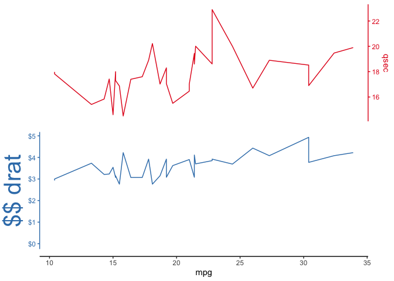

```r
# particularly useful is also the possibility to modify individual scales
mtcars |>
  ggstackplot(
    x = mpg, y = c(qsec, drat),
    color = c("#E41A1C", "#377EB8"),
    template = ggplot() + geom_line() + theme_stackplot(),
    add = list(
      # modify the axis for the second plot
      drat =
        scale_y_continuous("$$ drat",  labels = scales::label_dollar()) +
        expand_limits(y = 0) +
        theme(axis.title.y = element_text(size = 30))
    )
  )
```

## Legend positioning

Another example of theme modification is the use of the `add` argument to specify legend positioning.

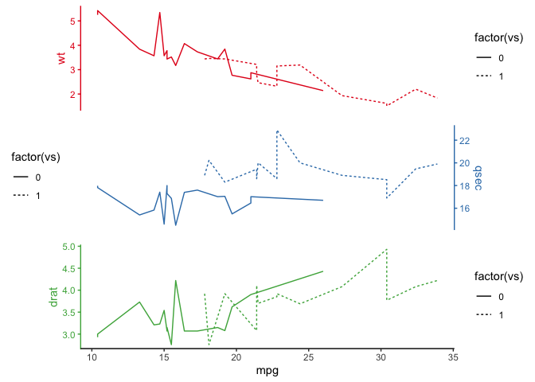

```r
mtcars |>
  ggstackplot(
    x = mpg,  y = c(wt, qsec, drat),
    color = c("#E41A1C", "#377EB8", "#4DAF4A"),
    template =
      ggplot() + aes(linetype = factor(vs)) +
      geom_line() + theme_stackplot(),
    # switch legend position for middle plot
    add = list(qsec = theme(legend.position = "left"))
  )
```

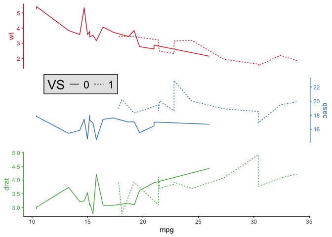

```r
mtcars |>
  ggstackplot(
    x = mpg,  y = c(wt, qsec, drat),
    color = c("#E41A1C", "#377EB8", "#4DAF4A"),
    template =
      ggplot() +
      aes(linetype = factor(vs)) +
      geom_line() +
      theme_stackplot() +
      # remove the legends, then...
      theme(legend.position = "none"),
    # ... re-include the middle panel legend on the plot
    # with some additional styling
    add = list(
      qsec =
        theme(
          # define legend relative position in x,y:
          legend.position = c(0.2, 0.9),
          # other legend stylistic changes:
          legend.title = element_text(size = 20),
          legend.text = element_text(size = 16),
          legend.background = element_rect(
            color = "black", fill = "gray90", linewidth = 0.5),
          legend.key = element_blank(),
          legend.direction = "horizontal"
        ) +
        labs(linetype = "VS")
    )
  )
```

# Putting it all together

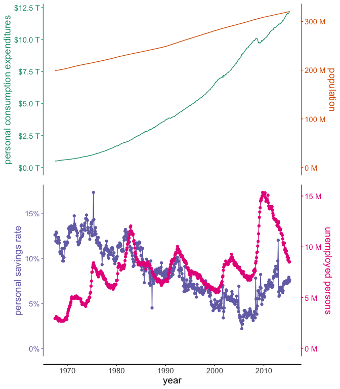

```r
# example from the README with economics data bundled with ggplot2
ggplot2::economics |>
  ggstackplot(
    # define shared x axis
    x = date,
    # define the stacked y axes
    y = c(pce, pop, psavert, unemploy),
    # pick the RColorBrewer Dark2 palette (good color contrast)
    palette = "Dark2",
    # overlay the pce & pop plots (1), then make a full break (0) to the once
    # again overlaye psavert & unemploy plots (1)
    overlap = c(1, 0, 1),
    # switch axes so unemploy and psavert are on the side where they are
    # highest, respectively - not doing this here by changing the order of y
    # because we want pop and unemploy on the same side
    switch_axes = TRUE,
    # make shared axis space a bit smaller
    shared_axis_size = 0.15,
    # provide a base plot with shared graphics eelements among all plots
    template =
      # it's a ggplot
      ggplot() +
      # use a line plot for all
      geom_line() +
      # we want the default stackplot theme
      theme_stackplot() +
      # add custom theme modifications, such as text size
      theme(text = element_text(size = 14)) +
      # make the shared axis a date axis
      scale_x_date("year") +
      # include y=0 for all plots to contextualize data better
      expand_limits(y = 0),
    # add plot specific elements
    add =
      list(
        pce =
          # show pce in trillions of dollars
          scale_y_continuous(
            "personal consumption expenditures",
            # always keep the secondary axis duplicated so ggstackplot can
            # manage axis placement for you
            sec.axis = dup_axis(),
            # labeling function for the dollar units
            labels = function(x) sprintf("$%.1f T", x/1000),
          ),
        pop =
          # show population in millions
          scale_y_continuous(
            "population", sec.axis = dup_axis(),
            labels = function(x) sprintf("%.0f M", x/1000)
          ),
        psavert =
          # savings is in %
          scale_y_continuous(
            "personal savings rate", sec.axis = dup_axis(),
            labels = function(x) paste0(x, "%"),
          ) +
          # show data points in addition to line
          geom_point(),
        unemploy =
          # unemploy in millions
          scale_y_continuous(
            "unemployed persons", sec.axis = dup_axis(),
            labels = function(x) sprintf("%.0f M", x/1000)
          ) +
          # show data points in addition to line
          geom_point()
      )
  )
```

# Advanced

Instead of calling `ggstackplot()` to make a plot, you can also use `prepare_stackplot()` and `assemble_stackplot()` to separate the two main steps of making a ggstackplot. `prepare_stackplot()` provides a tibble with all the plot components that can be modified directly in the tibble if so desired before assembling the plot with `assemble_stackplot()`. Usuallyt this is not necessary because the combination of the `template` and `add` parameters in `ggstackplot()` provides the same kind of flexibility as modifying plot elements in the plot tibble.

```r
# prep plot
plot_prep <-
  mtcars |>
  prepare_stackplot(
    x = mpg, y = c(wt, qsec),
    palette = "Set1"
  )

# show plot tibble
plot_prep
```

```
#> # A tibble: 2 × 6
#>   .var  config           data               plot   theme   add
#>   <chr> <list>           <list>             <list> <list>  <list>
#> 1 wt    <tibble [1 × 9]> <tibble [32 × 11]> <gg>   <theme> <NULL>
#> 2 qsec  <tibble [1 × 9]> <tibble [32 × 11]> <gg>   <theme> <NULL>
```

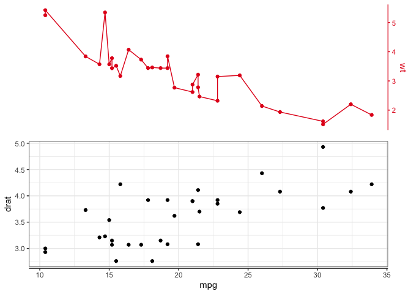

```r
# modify plot tibble
plot_prep$plot[[2]] <- ggplot(mtcars) + aes(mpg, drat) + geom_point()
plot_prep$theme[[2]] <- theme_bw()

# assemble stackplot
plot_prep |> assemble_stackplot()
```